# ED-Report 6 (Data summary and matching fr preventable AE)

15/8/2024

### **1- DATA SUMMARY**:

In this section, we investigated the raw data to see any potential specific pattern in the data. First, we checked number of **Preventable AE** and its ratio in **each quarter**:

**================ Precentage of AEoutcome in each quarter ================**

```
##         FALSE TRUE Precentage
## 2014 Q4   888   38 0.04103672
## 2015 Q1  1824   68 0.03594080
## 2015 Q2  1680   70 0.04000000
## 2015 Q3  1195   46 0.03706688
## 2015 Q4   556   12 0.02112676
```

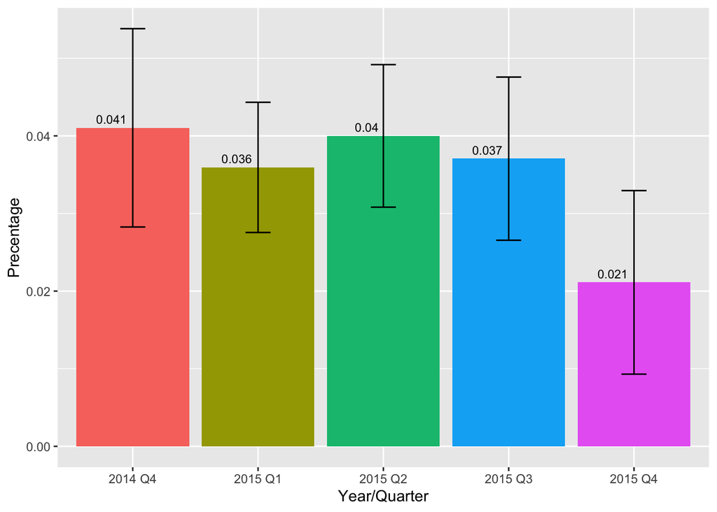

As it can be seen from the above table, the ratio of AE in each quarter is almost consistent. With the same appraoch we can find the ratio of **Preventable AE** in each **site**

**================ Precentage of AEoutcome in each site ================**

```
##   FALSE TRUE Precentage
## 0   870   32 0.03547672
## 1   619   25 0.03881988
## 2   889   16 0.01767956
## 3   500   24 0.04580153
## 4   463   26 0.05316973
## 5   826   32 0.03729604
## 6   931   45 0.04610656
## 7   617   16 0.02527646
## 8   428   18 0.04035874
```

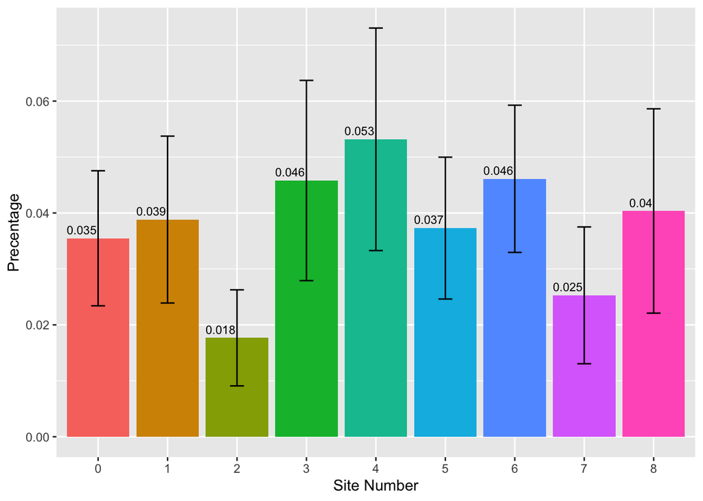

#### **1-1- Feature 1: LOS (Length of Stay)**

```
##    Min. 1st Qu.  Median    Mean 3rd Qu.    Max.    NA's
##     4.0    95.0   156.0   194.6   244.0  1685.0      48
```

We must also remember that we have **48 NA** values for LOS feature. We probably need to remove these observations in future analysis as imputing these values may result in wrong number and will affect our analysis. To investigate this feature more, we can visualize average of LOS for each type AEoutcome as shown below:

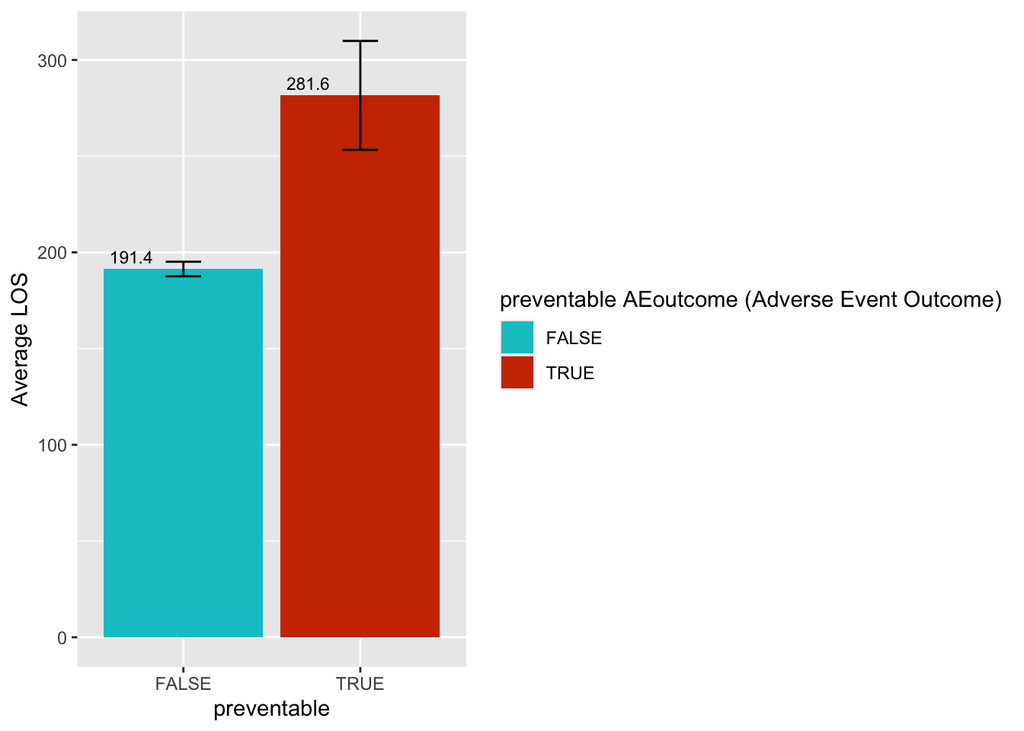

We can also plot average LOS for each site for each type of AEoutcome as shown below:

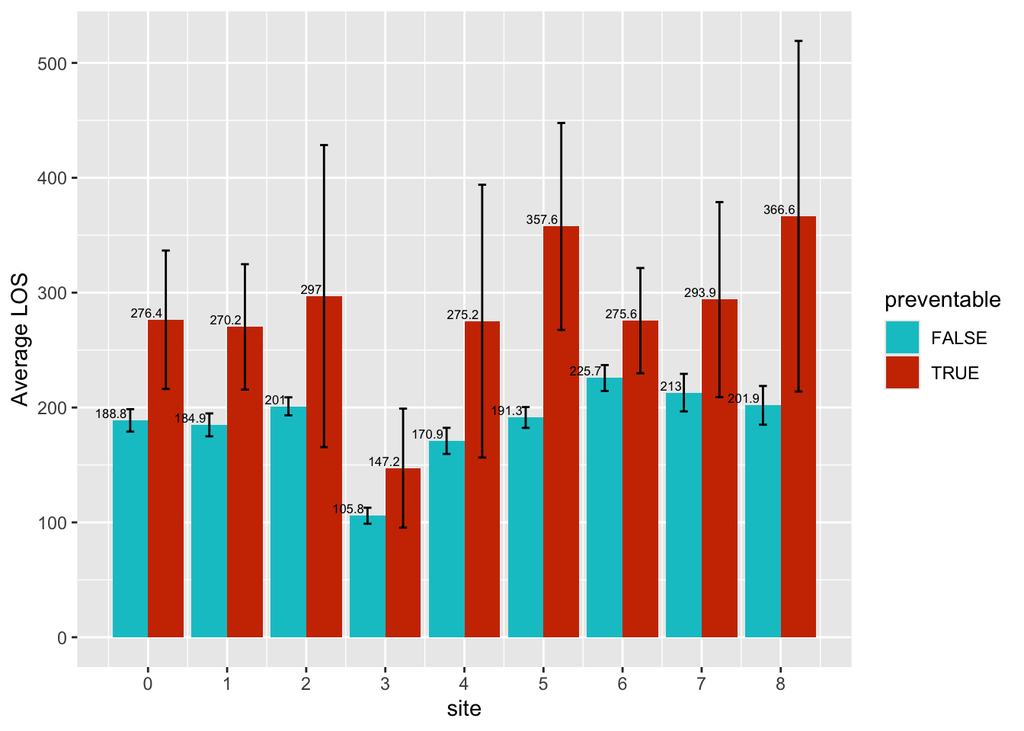

#### **1-2- Feature 2: ageyrs**

With the same approach as we showed for LOS, we can investigate age parameter as well.

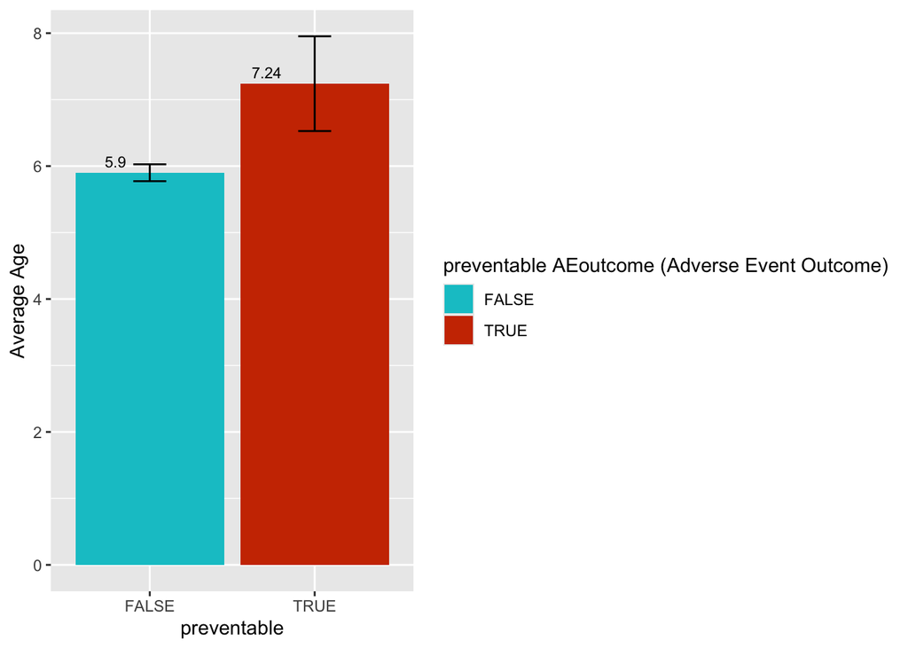

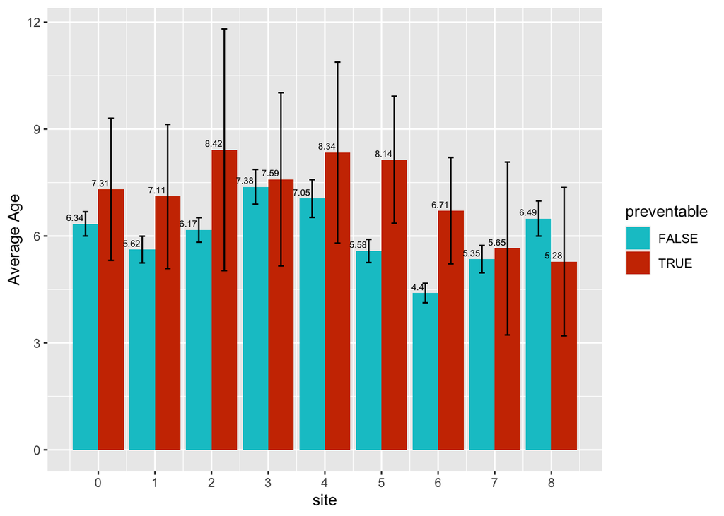

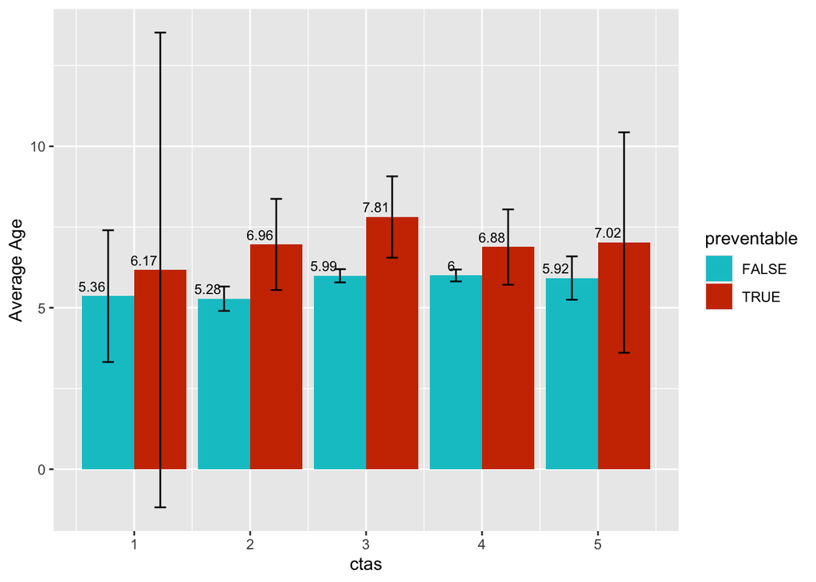

#### **1-4- Feature 4: ctas**

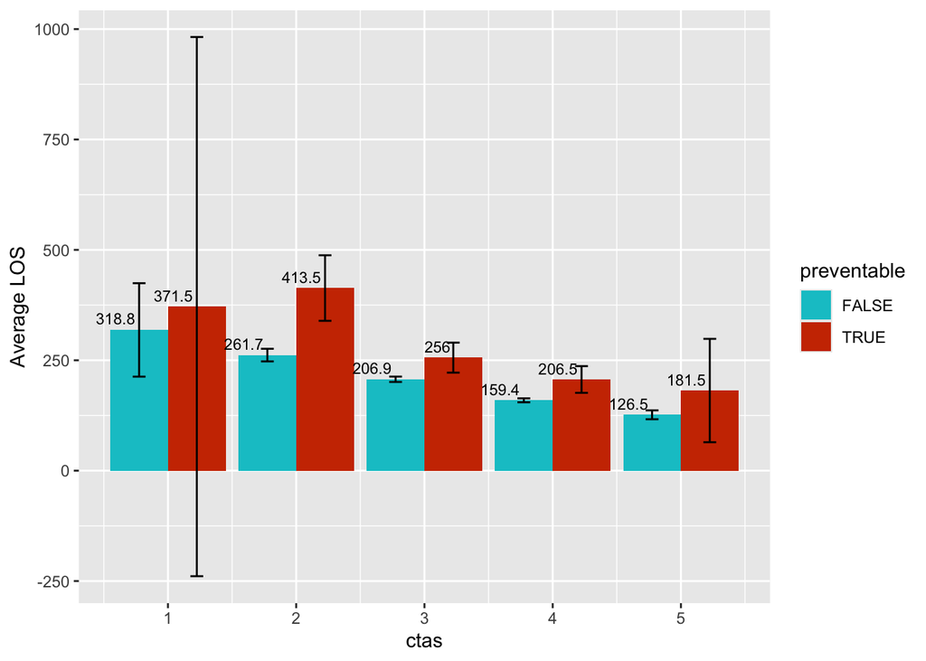

#### **1-5- Feature 5: shift_block**

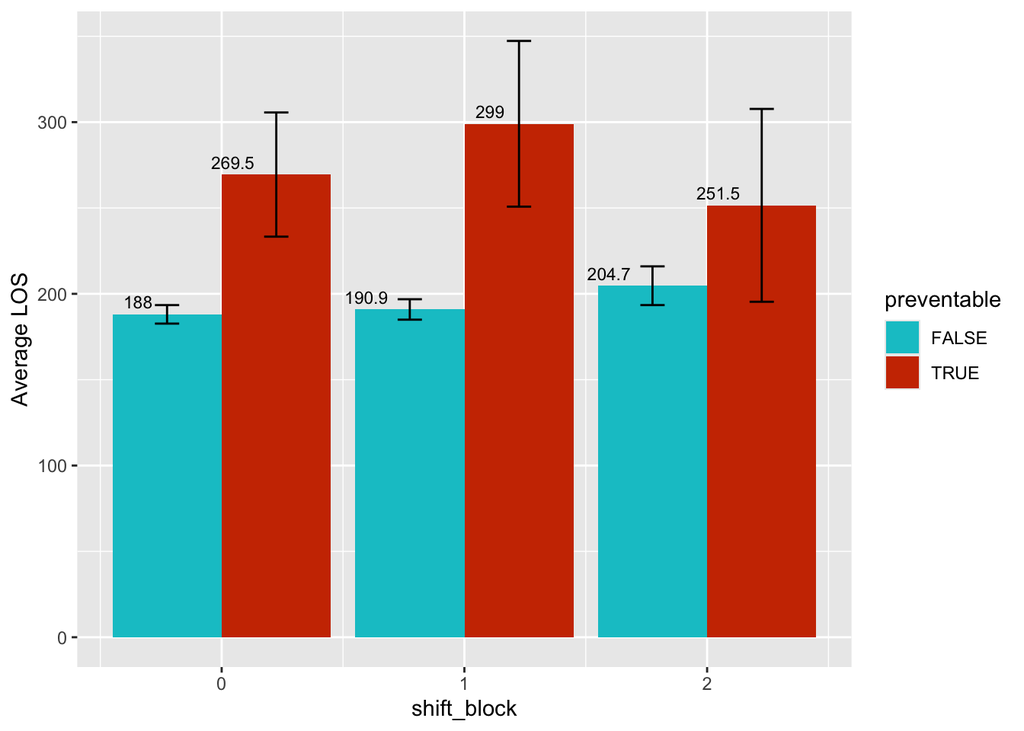

### **2- Matching**

In order to investigate the effect of **LOS** feature on **preventable AE**, we can use matching algorithm to find similar cases with negative and positive AEoutcome, put these cases in two different groups and then investigate the relationship between LOS for matched groups. To do this, we selected features that are listed below:

- shift_block
- ageyrs
- site
- ctas
- los

  In order to match cases from positive and negative preventable AE we will go through these steps:

1- Creating two pools of data. One for positive and one for negative preventable AEoutcome **Please note that since “LOS” is the parameter of interest, there is no point to for keeping NA values, so we removed rows which contained NA in LOS column.**

2- Preparing dataset to pass it to **“Fuzzyjoin”** function

3- Using “Fuzzyjoin” for matching data:

In order to find matches between two dataframes, we are going to use “Fuzzymatch”. The procedure we decided to use for matching is explained below:

- **Exact** matching for site feature
- **Exact** matching for ctas feature
- **Exact** matching for shift_block feature
- ageyrs within the range of **-20% and +20%** is considered as match value

Below is the result of matching algorithm:

| record_id | shift_block | ageyrs | site | ctas | los | avg_los_shift | shift_los_cat | preventable | ageyrs_start | ageyrs_end | shift_date.y | shift_block_n | ageyrs_n | site_n | ctas_n | los_n | avg_los_shift_n | shift_los_cat_n | preventable_n |
| --- | --- | --- | --- | --- | --- | --- | --- | --- | --- | --- | --- | --- | --- | --- | --- | --- | --- | --- | --- |
| 463-1012 | 1 | 12 | 0 | 2 | 184 | 235 | TRUE | TRUE | 9.6 | 14.4 | 2015-06-07 | 1 | 14.00 | 0 | 2 | 476 | 235.0000 | TRUE | FALSE |
| 463-1012 | 1 | 12 | 0 | 2 | 184 | 235 | TRUE | TRUE | 9.6 | 14.4 | 2015-06-07 | 1 | 14.00 | 0 | 2 | 251 | 235.0000 | TRUE | FALSE |
| 463-1012 | 1 | 12 | 0 | 2 | 184 | 235 | TRUE | TRUE | 9.6 | 14.4 | 2015-07-28 | 1 | 14.25 | 0 | 2 | 172 | 211.7143 | TRUE | FALSE |
| 463-1012 | 1 | 12 | 0 | 2 | 184 | 235 | TRUE | TRUE | 9.6 | 14.4 | 2015-07-28 | 1 | 10.92 | 0 | 2 | 335 | 211.7143 | TRUE | FALSE |
| 463-1012 | 1 | 12 | 0 | 2 | 184 | 235 | TRUE | TRUE | 9.6 | 14.4 | 2015-10-24 | 1 | 13.00 | 0 | 2 | 75 | 186.1250 | TRUE | FALSE |
| 463-1012 | 1 | 12 | 0 | 2 | 184 | 235 | TRUE | TRUE | 9.6 | 14.4 | 2014-12-13 | 1 | 11.42 | 0 | 2 | 131 | 200.8889 | TRUE | FALSE |
| 463-1012 | 1 | 12 | 0 | 2 | 184 | 235 | TRUE | TRUE | 9.6 | 14.4 | 2015-01-15 | 1 | 14.33 | 0 | 2 | 368 | 394.1818 | TRUE | FALSE |
| 463-1012 | 1 | 12 | 0 | 2 | 184 | 235 | TRUE | TRUE | 9.6 | 14.4 | 2015-02-18 | 1 | 11.08 | 0 | 2 | 168 | 467.8571 | TRUE | FALSE |
| 463-1012 | 1 | 12 | 0 | 2 | 184 | 235 | TRUE | TRUE | 9.6 | 14.4 | 2015-04-13 | 1 | 13.33 | 0 | 2 | 200 | 242.7000 | TRUE | FALSE |
| 463-1012 | 1 | 12 | 0 | 2 | 184 | 235 | TRUE | TRUE | 9.6 | 14.4 | 2015-04-13 | 1 | 10.75 | 0 | 2 | 143 | 242.7000 | TRUE | FALSE |

In the above table, the first 12 columns are related to positive AEoutcome group and the next columns are found matches from negative AEoutcome group. **Note that for one observation from positive AEoutcome group, we can have more than 1 match from negative AEoutcome group**. Since for each observation we can have multiple matches, we took an average from “LOS” of matches. Now we can compare the average “LOS” for different groups (negative and positive AEoutcome).

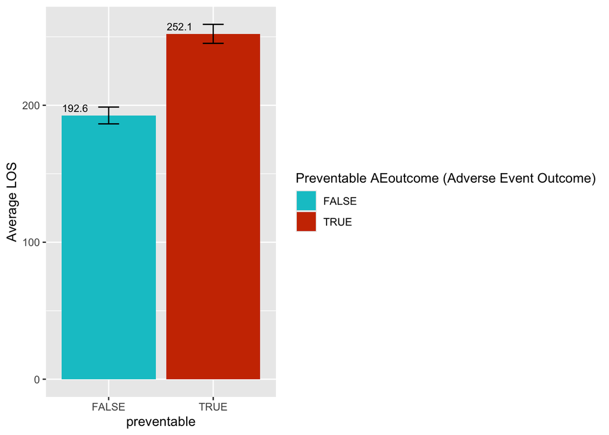

We can also compare the average LOS for matched data for different ctas:

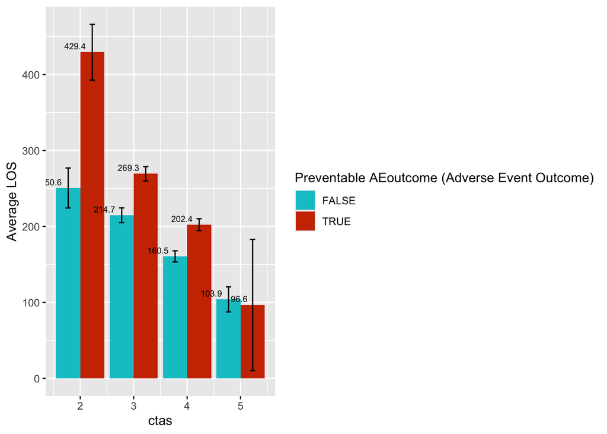

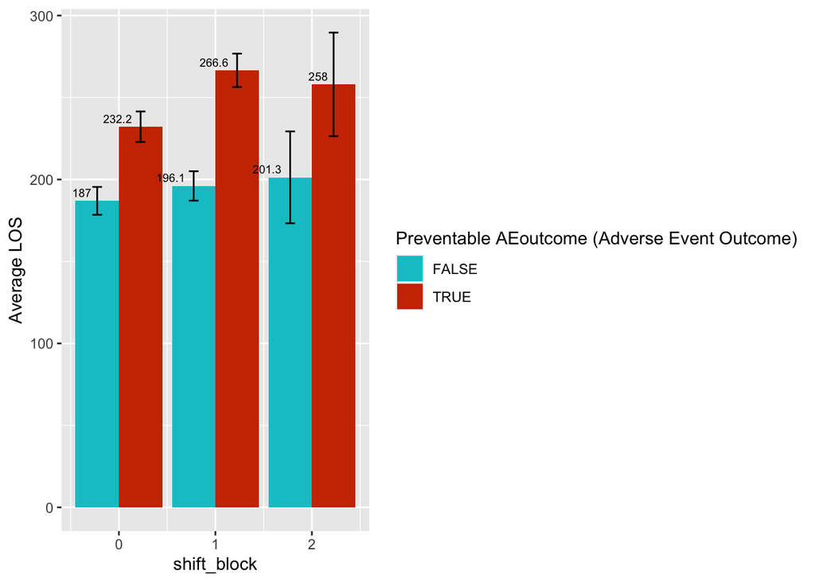

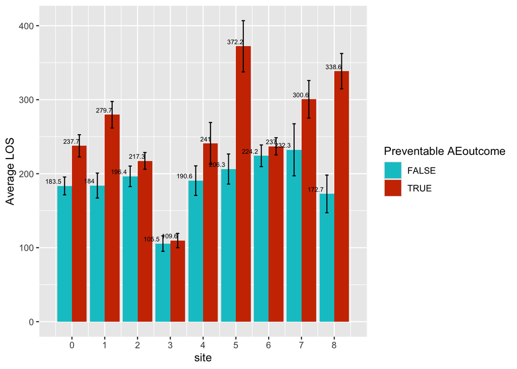

Same as before, we ended up with the same trend for variation of LOS. AS it’s represented, the average LOS for patients with positive AEoutcome in all sites are longer than patients with negative AEoutcome.